# Practical 3 (Fundamental Techniques in Data Science with R)

Amanda Ferraboli

2023-11-27

## Introduction

```r
library(tidyverse)
library(ggplot2)
library(ggpubr)
library(kableExtra)
library(weathermetrics)
```

Let’s load the `mpg` dataset from `ggplot2`. `mpg` contains a subset of the fuel economy data. The data frame has 234 rows and 11 variables:

- manufacturer: manufacturer name
- model: model name
- displ: engine displacement in litres
- year: year of manufacture
- cyl: number of cyclinders
- trans: type of transmission
- drv: type of drive tran (f = front-wheel drive; r = rear-wheel drive; 4 = four-wheel drive)
- cty: city miles per gallon
- hwy: highway miles per gallon
- fl: fuel type
- class: type of car

```r
head(mpg)
```

```
## # A tibble: 6 × 11
##   manufacturer model displ  year   cyl trans      drv     cty   hwy fl    class
##   <chr>        <chr> <dbl> <int> <int> <chr>      <chr> <int> <int> <chr> <chr>
## 1 audi         a4      1.8  1999     4 auto(l5)   f        18    29 p     compa…
## 2 audi         a4      1.8  1999     4 manual(m5) f        21    29 p     compa…
## 3 audi         a4      2    2008     4 manual(m6) f        20    31 p     compa…
## 4 audi         a4      2    2008     4 auto(av)   f        21    30 p     compa…
## 5 audi         a4      2.8  1999     6 auto(l5)   f        16    26 p     compa…
## 6 audi         a4      2.8  1999     6 manual(m5) f        18    26 p     compa…
```

The `glimpse()` function can be used to get an overview of the dataframe structure. It is similar to `str()`, but more readable.

```r
glimpse(mpg)
```

```
## Rows: 234
## Columns: 11
## $ manufacturer <chr> "audi", "audi", "audi", "audi", "audi", "audi", "audi", "…
## $ model        <chr> "a4", "a4", "a4", "a4", "a4", "a4", "a4", "a4 quattro", "…
## $ displ        <dbl> 1.8, 1.8, 2.0, 2.0, 2.8, 2.8, 3.1, 1.8, 1.8, 2.0, 2.0, 2.…
## $ year         <int> 1999, 1999, 2008, 2008, 1999, 1999, 2008, 1999, 1999, 200…
## $ cyl          <int> 4, 4, 4, 4, 6, 6, 6, 4, 4, 4, 4, 6, 6, 6, 6, 6, 6, 8, 8, …
## $ trans        <chr> "auto(l5)", "manual(m5)", "manual(m6)", "auto(av)", "auto…
## $ drv          <chr> "f", "f", "f", "f", "f", "f", "f", "4", "4", "4", "4", "4…
## $ cty          <int> 18, 21, 20, 21, 16, 18, 18, 18, 16, 20, 19, 15, 17, 17, 1…
## $ hwy          <int> 29, 29, 31, 30, 26, 26, 27, 26, 25, 28, 27, 25, 25, 25, 2…
## $ fl           <chr> "p", "p", "p", "p", "p", "p", "p", "p", "p", "p", "p", "p…
## $ class        <chr> "compact", "compact", "compact", "compact", "compact", "c…
```

```r
# for comparison
str(mpg)
```

```
## tibble [234 × 11] (S3: tbl_df/tbl/data.frame)
##  $ manufacturer: chr [1:234] "audi" "audi" "audi" "audi" ...
##  $ model       : chr [1:234] "a4" "a4" "a4" "a4" ...
##  $ displ       : num [1:234] 1.8 1.8 2 2 2.8 2.8 3.1 1.8 1.8 2 ...
##  $ year        : int [1:234] 1999 1999 2008 2008 1999 1999 2008 1999 1999 2008 ...
##  $ cyl         : int [1:234] 4 4 4 4 6 6 6 4 4 4 ...
##  $ trans       : chr [1:234] "auto(l5)" "manual(m5)" "manual(m6)" "auto(av)" ...
##  $ drv         : chr [1:234] "f" "f" "f" "f" ...
##  $ cty         : int [1:234] 18 21 20 21 16 18 18 18 16 20 ...
##  $ hwy         : int [1:234] 29 29 31 30 26 26 27 26 25 28 ...
##  $ fl          : chr [1:234] "p" "p" "p" "p" ...
##  $ class       : chr [1:234] "compact" "compact" "compact" "compact" ...
```

### Question 1

Are there any variables that do not have the class you expect it to?

The categorical variables are listed as character variables . The best practice is to convert these categorical variables to factor variables. The advantage of using factors are a few, firstly, they can be correctly understood and used is statistical modeling, secondly, as studied during the lectures, some interesting graphics may use factor variables. We should convert these variables and expect the class factor instead.

### Question 2

Make any changes you feel are necessary.

```r
# method 1: using lapply()

# find and return chr variables by:
# 1. use sapply() and is.character to find chr columns and return them as logical (TRUE is chr)
# 2. filter the original dataframe to select only the chr variables
# 3. obtain the chr variable names with colnames()
chr_variables <- colnames(mpg[,sapply(mpg,is.character)])

# convert chr variables to factors
mpg[chr_variables] <- lapply(mpg[chr_variables], as.factor)

# method 2: using mutate_if(), quicker and much more readable
mpg <- mpg %>%
  mutate_if(is.character, as.factor)

glimpse(mpg)
```

```
## Rows: 234
## Columns: 11
## $ manufacturer <fct> audi, audi, audi, audi, audi, audi, audi, audi, audi, aud…
## $ model        <fct> a4, a4, a4, a4, a4, a4, a4, a4 quattro, a4 quattro, a4 qu…
## $ displ        <dbl> 1.8, 1.8, 2.0, 2.0, 2.8, 2.8, 3.1, 1.8, 1.8, 2.0, 2.0, 2.…
## $ year         <int> 1999, 1999, 2008, 2008, 1999, 1999, 2008, 1999, 1999, 200…
## $ cyl          <int> 4, 4, 4, 4, 6, 6, 6, 4, 4, 4, 4, 6, 6, 6, 6, 6, 6, 8, 8, …
## $ trans        <fct> auto(l5), manual(m5), manual(m6), auto(av), auto(l5), man…
## $ drv          <fct> f, f, f, f, f, f, f, 4, 4, 4, 4, 4, 4, 4, 4, 4, 4, 4, r, …
## $ cty          <int> 18, 21, 20, 21, 16, 18, 18, 18, 16, 20, 19, 15, 17, 17, 1…
## $ hwy          <int> 29, 29, 31, 30, 26, 26, 27, 26, 25, 28, 27, 25, 25, 25, 2…
## $ fl           <fct> p, p, p, p, p, p, p, p, p, p, p, p, p, p, p, p, p, p, r, …
## $ class        <fct> compact, compact, compact, compact, compact, compact, com…
```

## Exploratory data analysis

### Non-Graphical EDA

Below `hwy` is summarised by vehicle class, by asking for commonly used summary statistics.

```r
mpg %>%
  group_by(class) %>%         # by class
  summarise(min = min(hwy),   # minimum of hwy
            mean = mean(hwy), # mean
            sd = sd(hwy),     # standard deviation
            max = max(hwy),   # maximum
            n = n())  %>%     # nr of observations
  kbl() %>%
  kable_styling(latex_options = c("striped", "hover"), full_width = F)
```

| class | min | mean | sd | max | n |
| --- | --- | --- | --- | --- | --- |
| 2seater | 23 | 24.80000 | 1.303840 | 26 | 5 |
| compact | 23 | 28.29787 | 3.781620 | 44 | 47 |
| midsize | 23 | 27.29268 | 2.135930 | 32 | 41 |
| minivan | 17 | 22.36364 | 2.062655 | 24 | 11 |
| pickup | 12 | 16.87879 | 2.274280 | 22 | 33 |
| subcompact | 20 | 28.14286 | 5.375012 | 44 | 35 |
| suv | 12 | 18.12903 | 2.977973 | 27 | 62 |

### Question 3

Create a summary of engine displacement by year, including the minimum, maximum, median, and inter quantile range.

```r
mpg %>%
  group_by(year) %>%                    # by year
  summarise(min = min(displ),           # minimum of engine disp
            max = max(displ),           # maximum
            Q1 = quantile(displ, 0.25), # 1st quartile
            median = median(displ),     # median, 2nd quartile
            Q3 = quantile(displ, 0.75)  # 3rd quartile
  ) %>%
  kbl() %>%
  kable_styling(latex_options = c("striped", "hover"), full_width = F)
```

| year | min | max | Q1 | median | Q3 |
| --- | --- | --- | --- | --- | --- |
| 1999 | 1.6 | 6.5 | 2.2 | 3.0 | 4.0 |
| 2008 | 1.8 | 7.0 | 2.5 | 3.6 | 4.7 |

### Graphical EDA

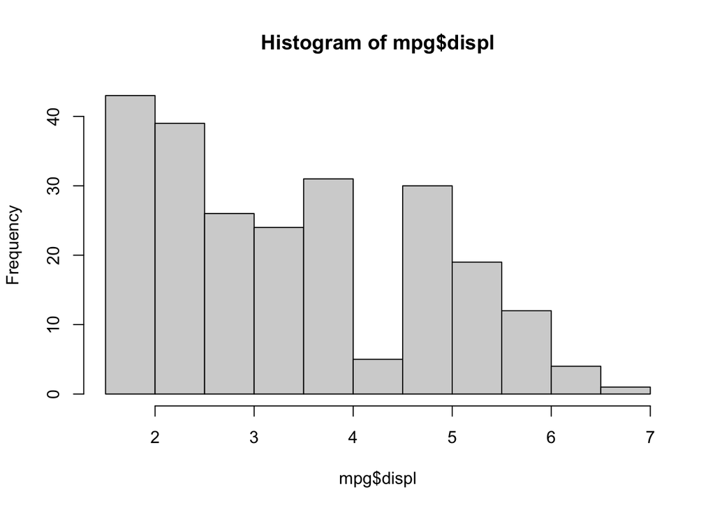

```r
# testing base R functions plot(), hist(), barplot()
hist(mpg$displ)
```

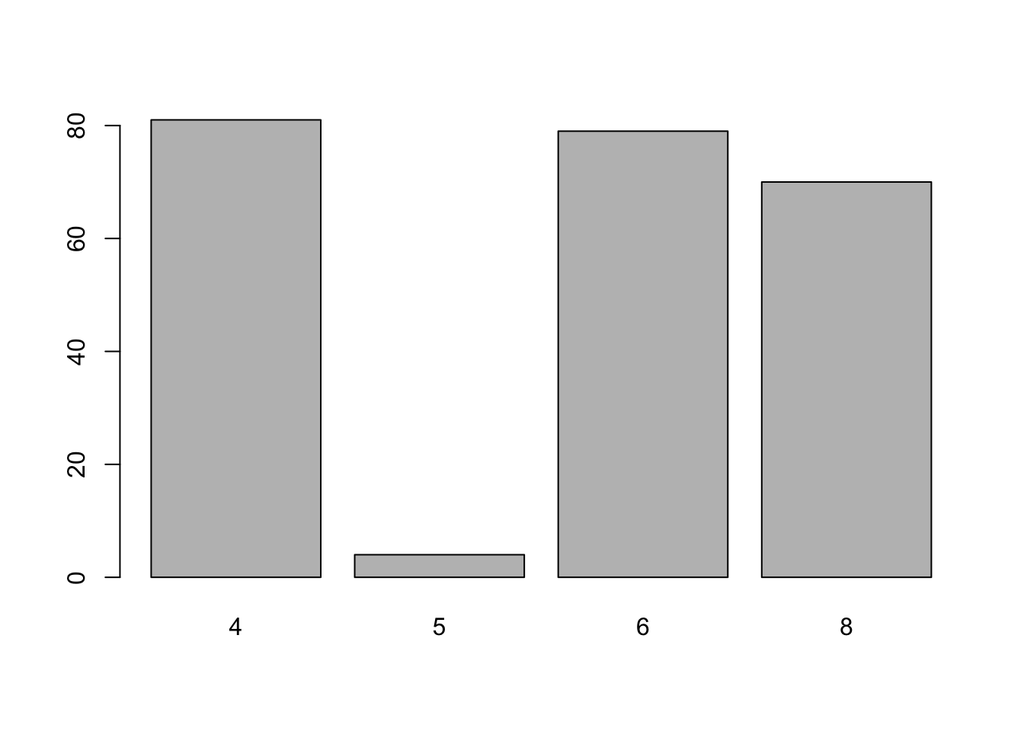

```r
barplot(table(mpg$cyl))
```

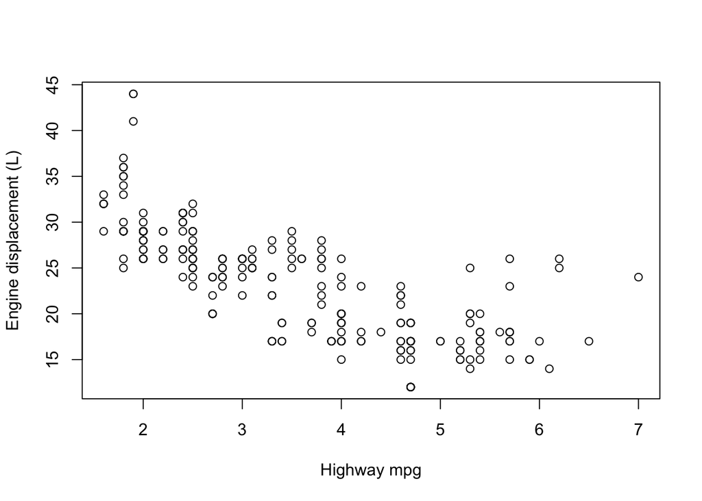

```r
plot(x = mpg$displ, y = mpg$hwy,
     xlab = "Highway mpg",
     ylab = "Engine displacement (L)")
```

General ggplot template:

````r
```{r}
ggplot(data = <DATA>) +
  <GEOM_FUNCTION>(
     mapping = aes(<MAPPINGS>)) +
  <COORDINATE_FUNCTION> +
  <FACET_FUNCTION> +
  <THEME>
```
````

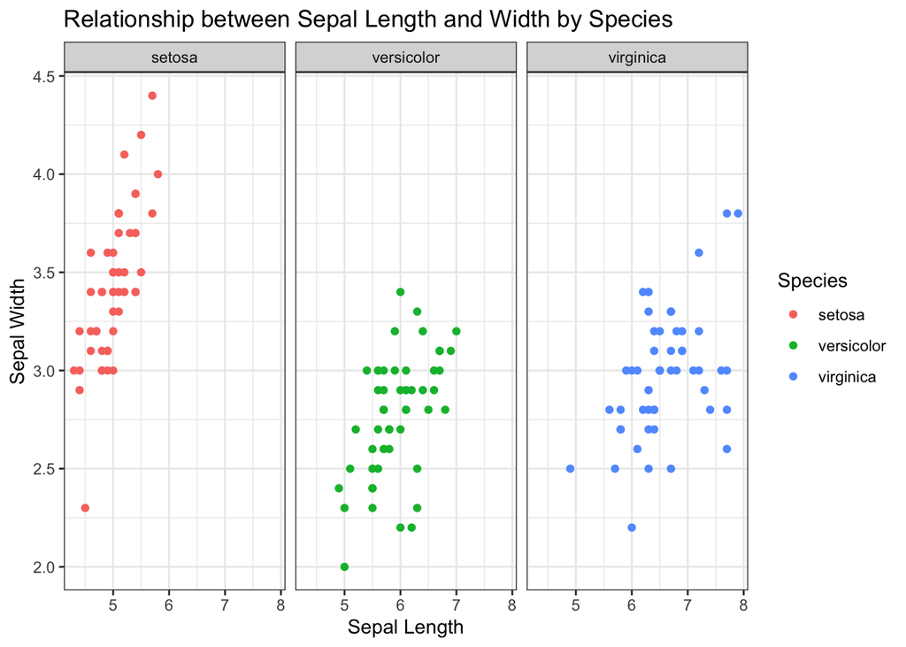

```r
ggplot(iris) + # Data
  geom_point(mapping = aes(x = Sepal.Length, # Variable on the x-axis
                           y = Sepal.Width, # Variable on the y-axis
                           colour = Species)) + # Legend
  labs(x = "Sepal Length",
       y = "Sepal Width",
       title = "Relationship between Sepal Length and Width by Species") +
  coord_cartesian() + # Default standard for mapping x and y
  facet_wrap(~Species) + # Splits plot by the species variable
  theme_bw() # Sets the background theme
```

#### Visualising distributions of single variables

#### Categorical variables

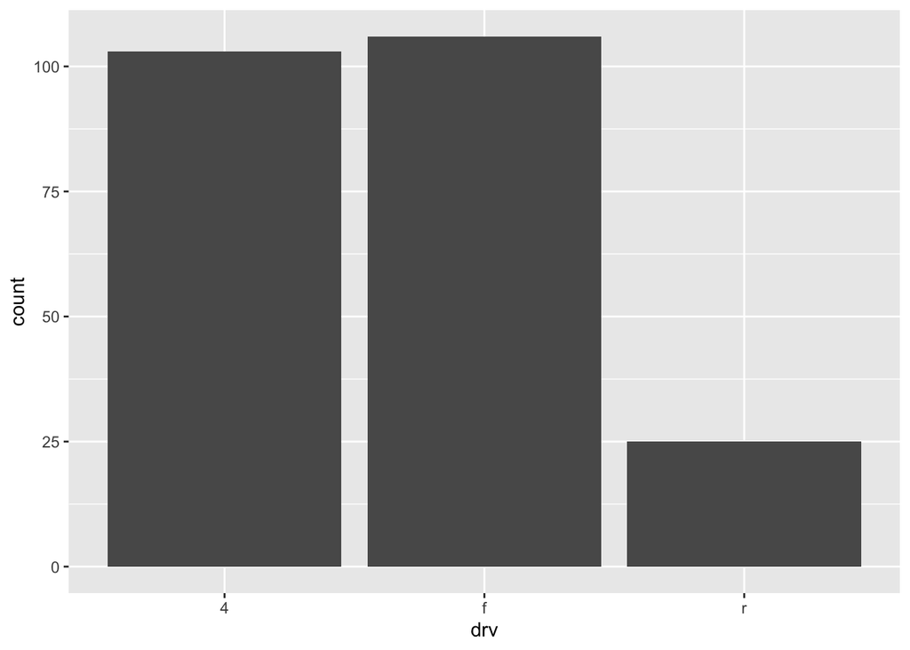

```r
ggplot(mpg) +             # data element (mpg)
  geom_bar(aes(x = drv)) # geom_function (bar plot)
```

#### Question 4

Create a bar chart that shows a count for the different vehicle classes in mpg.

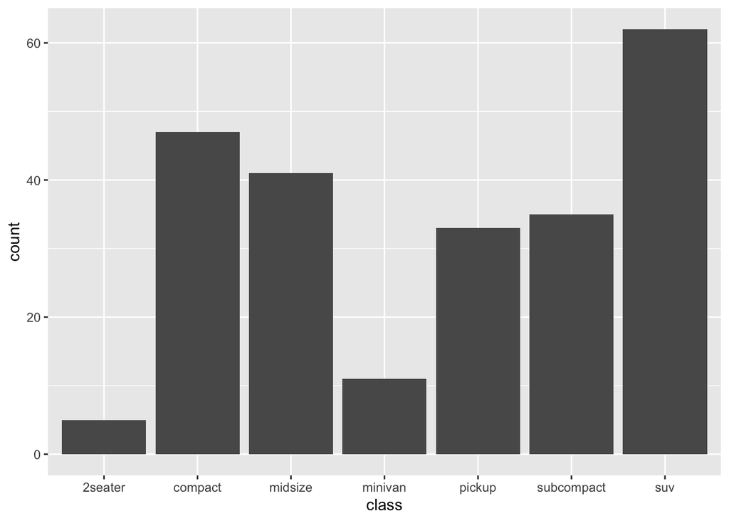

```r
ggplot(mpg) +               # data element (mpg)
  geom_bar(aes(x = class))  # geom_function (bar plot) with variable 'class' to be shown on axis x.
```

#### Question 5

Look up different ggplot themes, and apply one to the bar chart you just created.

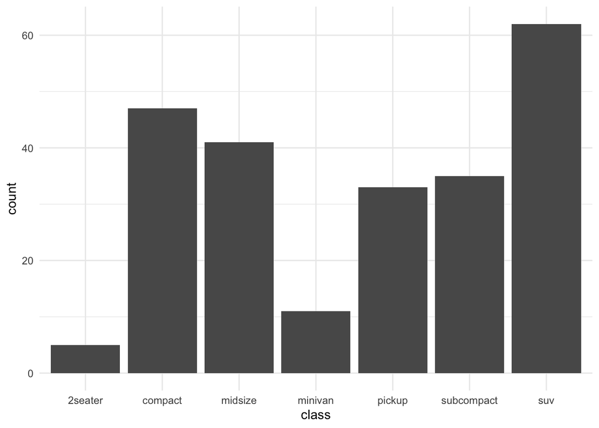

```r
ggplot(mpg) +               # data element (mpg)
  geom_bar(aes(x = class)) + # geom_function (bar plot) with variable 'class' to be shown on axis x
  theme_minimal()
```

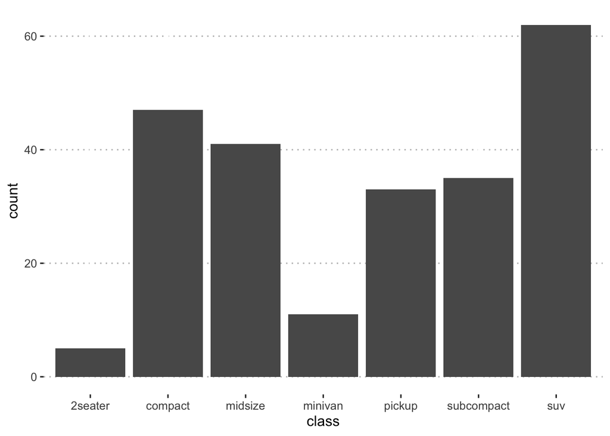

```r
ggplot(mpg) +               # data element (mpg)
  geom_bar(aes(x = class)) + # geom_function (bar plot) with variable 'class' to be shown on axis x
  theme_pubclean()
```

#### Continuous variables

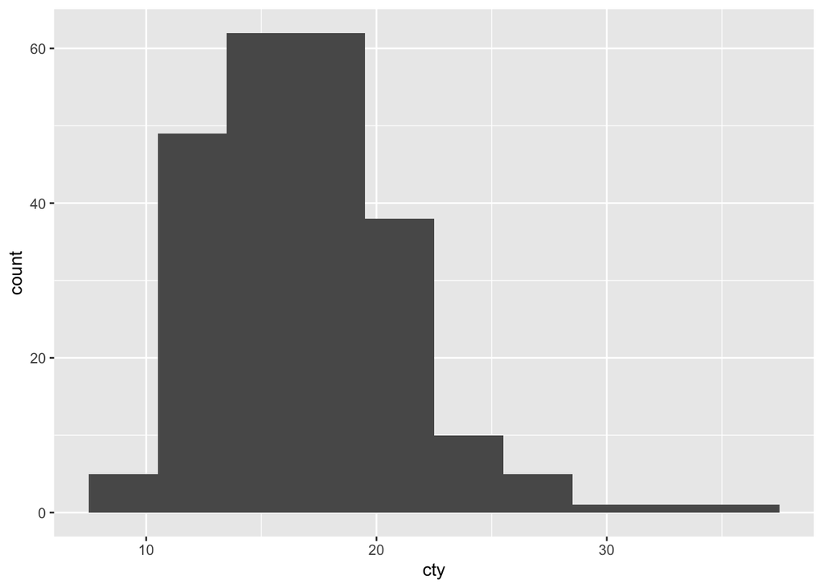

```r
ggplot(mpg) +
  geom_histogram(aes(x = cty),
                 binwidth = 3)
```

#### Question 6

What happens when you change the value of binwidth to 1? Does the distribution change?

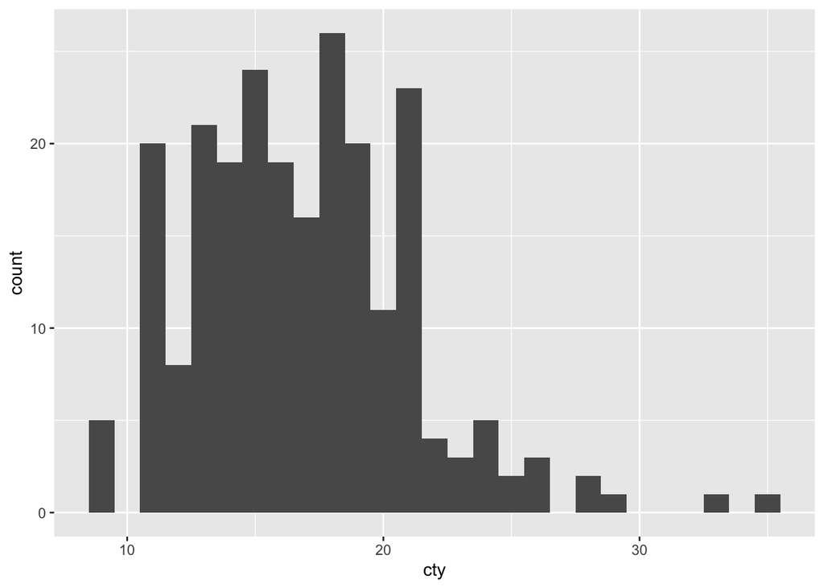

```r
ggplot(mpg) +
  geom_histogram(aes(x = cty),
                 binwidth = 1)
```

A `binwidth` of 1 is thinner than the one of 3, meaning it corresponds to a shorter interval of values. The distribution does not change significantly, but it becomes less smooth. It also reveals two interesting patterns: first, a peak at around `cty` = 21, almost as high as the interquartile ranges of Q1 = 14 and Q3 = 19, which was not visible in the previous histogram. Secondly, the outliers on the tail become more visible, there are two values of `cty` greater than 30 with very few cases that could be investigated.

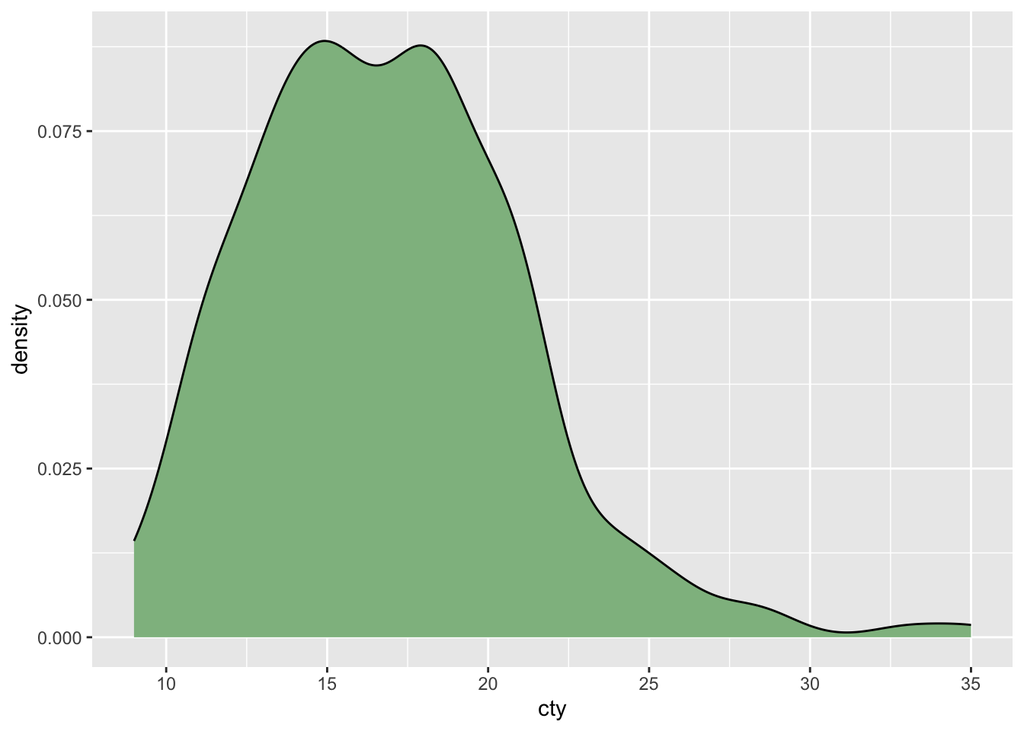

```r
ggplot(mpg, aes(x = cty)) +
  geom_density(fill = "darkseagreen")
```